# Análisis de Expresión Génica

Detección de expresión diferencial entre LUAD y LUSC

Noé Gragera Jiménez

3 de June, 2026

# 1. Obteción de Datos con TCGAbiolinks:

Para acceder a los datos de bulk RNA-seq, tanto de LUAS como LUAD, se utiliza TCGAbiolinks:

```r
library(TCGAbiolinks)
library(SummarizedExperiment)
library(dplyr)
library(here)

#LUAD DATA:
# Cargar datos adeocarcinoma pulmonar (LUAD):
LUAD_query <-  GDCquery(
  project = "TCGA-LUAD",
  data.category = "Transcriptome Profiling",
  data.type = "Gene Expression Quantification",
  workflow.type = "STAR - Counts"
)

GDCdownload(LUAD_query)

# Obtener SummarizedExperimet de LUAD:
LUAD_data_bulkRNA <- GDCprepare(LUAD_query)
saveRDS(LUAD_data_bulkRNA,"/Users/noegragerajimenez/Documents/TFM/Analysis RStudio/Scripts/Análisis Transcriptómico/bulkRNAseq_data/LUAD_SummarizedExperiment.rds")

################################################################################

#LUSC DATA:
# Cargar datos carcinoma escamoso pulmonar (LUSC):
LUSC_query <- GDCquery(project = "TCGA-LUSC",
  data.category = "Transcriptome Profiling",
  data.type = "Gene Expression Quantification",
  workflow.type = "STAR - Counts")

GDCdownload(LUSC_query)

# Obtener Summarized experiment de LUSC:
LUSC_data_bulkRNA <- GDCprepare(LUSC_query)
saveRDS(LUSC_data_bulkRNA,"/Users/noegragerajimenez/Documents/TFM/Analysis RStudio/Scripts/Análisis Transcriptómico/bulkRNAseq_data/LUSC_SummarizedExperiment.rds")
```

# 2. Tractamiento de los Summarized Experiments:

```r
library(janitor)
library(org.Hs.eg.db)

#Leer SummarizedExperiment:
LUAD_bulkRNA_complete <- readRDS("/Users/noegragerajimenez/Documents/TFM/Analysis RStudio/Scripts/Análisis Transcriptómico/bulkRNAseq_data/LUAD_SummarizedExperiment.rds")
LUSC_bulkRNA_complete <- readRDS("/Users/noegragerajimenez/Documents/TFM/Analysis RStudio/Scripts/Análisis Transcriptómico/bulkRNAseq_data/LUSC_SummarizedExperiment.rds")

#Filtrar por muestras tumorales:
LUAD_bulkRNA <- LUAD_bulkRNA_complete[ ,LUAD_bulkRNA_complete$shortLetterCode=="TP"]
LUSC_bulkRNA <- LUSC_bulkRNA_complete[ ,LUSC_bulkRNA_complete$shortLetterCode=="TP"]

#Extracción de matrices de conteos:
LUAD_mat <- assay(LUAD_bulkRNA)
LUSC_mat <- assay(LUSC_bulkRNA)


# Cambiar ensembl a Sympol de LUAD:
LUAD_genes<- rownames(LUAD_mat) %>%
  tibble::enframe() %>%
  mutate(ENSEMBL =stringr::str_replace(value, "\\.[0-9]+", ""))



LUAD_gene_map<- clusterProfiler::bitr(LUAD_genes$ENSEMBL,
                                           fromType = "ENSEMBL",
                                           toType = "SYMBOL",
                                           OrgDb = org.Hs.eg.db) %>%
  distinct(SYMBOL, .keep_all = TRUE)


LUAD_gene_map<- LUAD_gene_map %>%
  left_join(LUAD_genes)


LUAD_mat<- LUAD_mat[LUAD_gene_map$value, ]
row.names(LUAD_mat)<- LUAD_gene_map$SYMBOL

#############################################

LUSC_genes<- rownames(LUSC_mat) %>%
  tibble::enframe() %>%
  mutate(ENSEMBL =stringr::str_replace(value, "\\.[0-9]+", ""))


LUSC_gene_map<- clusterProfiler::bitr(LUSC_genes$ENSEMBL,
                                           fromType = "ENSEMBL",
                                           toType = "SYMBOL",
                                           OrgDb = org.Hs.eg.db) %>%
  distinct(SYMBOL, .keep_all = TRUE)


LUSC_gene_map<- LUSC_gene_map %>%
  left_join(LUSC_genes)


LUSC_mat<- LUSC_mat[LUSC_gene_map$value, ]
row.names(LUSC_mat)<- LUSC_gene_map$SYMBOL
```

```r
#Comprobación de que son los mismos genes:
all.equal(rownames(LUAD_mat), rownames(LUSC_mat))
```

```
## [1] TRUE
```

# 3. Graficación perfiles tumorales (TP) LUSC y LUAD con PCA:

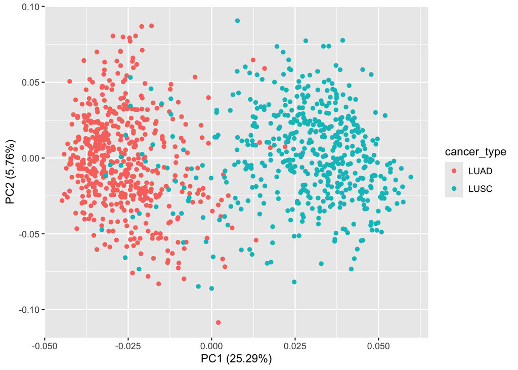

```r
library(ggfortify)
library(DESeq2)

lung_mat<- cbind(LUAD_mat, LUSC_mat)
lung_meta<- data.frame(cancer_type = c(rep( "LUAD", ncol(LUAD_mat)),
                   rep("LUSC", ncol(LUSC_mat))))

rownames(lung_meta) <- c(colnames(LUAD_mat), colnames(LUSC_mat)) #CHATOMICS esta al reves error!!


##---CPM Transformation---##
cpm <- edgeR::cpm(lung_mat, log = TRUE, prior.count = 1)

#Seleccionar genes más variables: los 1000 primeros
gene_idx <- order(rowVars(cpm), decreasing = TRUE)[1:1000]
cpm_sub <- cpm[gene_idx, ]

#PCA generica según los carcinomas:
pca <- prcomp(t(cpm_sub), scale. = TRUE)
autoplot(pca, data = lung_meta, color="cancer_type")
```

```r
head(sort(abs(pca$rotation[,1]), decreasing = TRUE), 20)
```

```
##         DSG3        CERS3         DSC3        KRT74         KRT5        S1PR5
##   0.05781639   0.05721923   0.05656075   0.05612518   0.05547006   0.05528480
##         BNC1       RAET1L    SERPINB13         RORC        KRT6B        HNF1B
##   0.05525071   0.05495469   0.05474345   0.05440241   0.05436925   0.05431144
##       CERNA2       CALML3        CLCA2 LOC105372126         TP63      GPR15LG
##   0.05413545   0.05393743   0.05389810   0.05379333   0.05365531   0.05362330
##       FAM83C        KRT6C
##   0.05353506   0.05351865
```

# 4. Cluster Jerárquico de perfiles tumorales (control calidad):

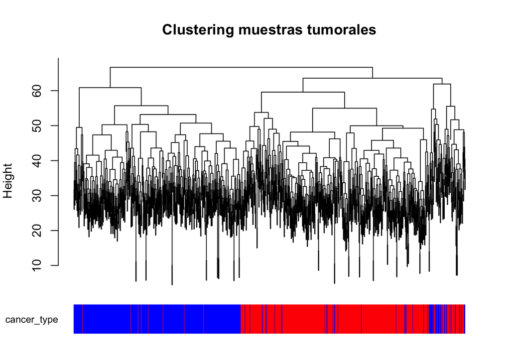

```r
cols <- ifelse(lung_meta$cancer_type == "LUAD", "red", "blue")
n <- length(cols)

#Hacer cluster jerarquico:
hc <- hclust(dist(scale(t(cpm_sub))), method = "complete")

#Especificar panel donde iran ambos plots:
layout(matrix(c(1, 2), nrow = 2), heights = c(4, 0.8))

#Graficar hclust:
par(mar = c(0, 4, 4, 2))
plot(hc, labels = FALSE, main = "Clustering muestras tumorales")

#Graficar barra muestral:
par(mar = c(2, 4, 0, 2))
plot(NULL, xlim = c(1, n), ylim = c(0, 1),
     axes = FALSE, ann = FALSE) #grafico vacio con limites igual al número de muestras para que encaje (xlim)
rect(xleft = 1:n -0.5,
     xright = 1:n +0.5,
     ybottom = 0,
     ytop = 1,
     col = cols[hc$order],
     border = NA) #rectangulo que rellenará el plot vacío
mtext("cancer_type", side = 2, at = 0.5, las = 1, cex = 0.8)
```

# 5. Proyectar biomarcadores especificos de cada tumor en PCA:

A continuación, para metodo de control y visualizar más en detalle las diferencias de cada carcinoma, se graficará las PCA en función del nivel de expresón https://pmc.ncbi.nlm.nih.gov/articles/PMC8233431/ genes biomarcadores para LUAD y LUSC:

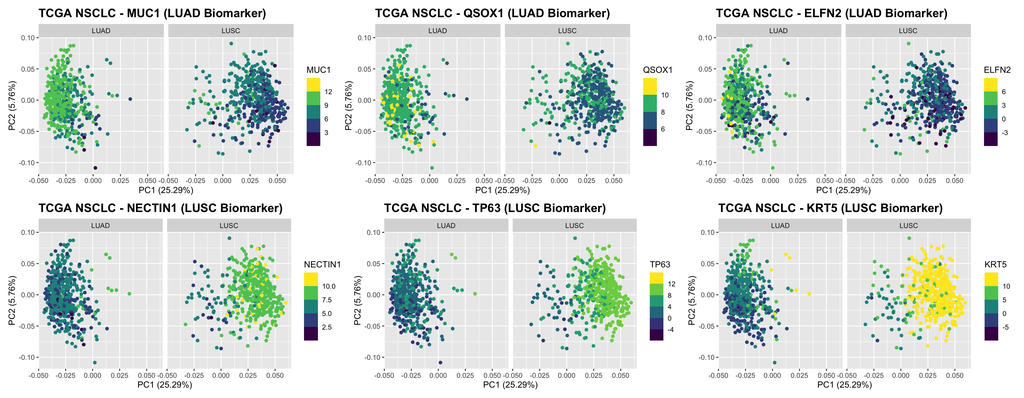

```r
#------------------PCA DE BIOMARCADORES DE LUAD------------------#

# 1. Poner conteos transformados cpm en metadata:
lung_meta$MUC1 <- cpm["MUC1",]
lung_meta$QSOX1 <- cpm["QSOX1",]
lung_meta$ELFN2 <- cpm["ELFN2",]

#2. Graficar:
#MUC1:
lung_meta$MUC1 <- pmin(lung_meta$MUC1, 16)
MUC1_PCA <- autoplot(pca, data = lung_meta , color ="MUC1") +
  scale_color_viridis_b() +
  facet_wrap(~ cancer_type) +
  ggtitle("TCGA NSCLC - MUC1 (LUAD Biomarker)") +
  theme(plot.title = element_text(size = 15, face = "bold"))

#QSOX1:
lung_meta$QSOX1 <- pmin(lung_meta$QSOX1, 16)
QSOX1_PCA <- autoplot(pca, data = lung_meta , color ="QSOX1") +
  scale_color_viridis_b() +
  facet_wrap(~ cancer_type) +
  ggtitle("TCGA NSCLC - QSOX1 (LUAD Biomarker)") +
  theme(plot.title = element_text(size = 15, face = "bold"))

#ELFN2:
lung_meta$ELFN2 <- pmin(lung_meta$ELFN2, 10)
ELFN2_PCA <- autoplot(pca, data = lung_meta , color ="ELFN2") +
  scale_color_viridis_b() +
  facet_wrap(~ cancer_type) +
  ggtitle("TCGA NSCLC - ELFN2 (LUAD Biomarker)") +
  theme(plot.title = element_text(size = 15, face = "bold"))

#-----------------------------------------------------------------------------#

#------------------PCA DE BIOMARCADORES DE LUSC:------------------#

# 1. Poner los conteos transformados a vsf en metadata:
lung_meta$NECTIN1 <- cpm["NECTIN1",]
lung_meta$TP63 <- cpm["TP63",]
lung_meta$KRT5 <- cpm["KRT5",]

#2. Graficar:
#NECTIN1:
lung_meta$NECTIN1 <- pmin(lung_meta$NECTIN1, 16)
NECTIN1_PCA <- autoplot(pca, data = lung_meta , color ="NECTIN1") +
  scale_color_viridis_b() +
  facet_wrap(~ cancer_type) +
  ggtitle("TCGA NSCLC - NECTIN1 (LUSC Biomarker)") +
  theme(plot.title = element_text(size = 15, face = "bold"))

#TP63:
lung_meta$TP63 <- pmin(lung_meta$TP63, 15)
TP63_PCA <- autoplot(pca, data = lung_meta , color ="TP63") +
  scale_color_viridis_b() +
  facet_wrap(~ cancer_type) +
  ggtitle("TCGA NSCLC - TP63 (LUSC Biomarker)") +
  theme(plot.title = element_text(size = 15, face = "bold"))

#KRT5:
lung_meta$KRT5 <- pmin(lung_meta$KRT5,15)
KRT5_PCA <- autoplot(pca, data = lung_meta , color ="KRT5") +
  scale_color_viridis_b() +
  facet_wrap(~ cancer_type) +
  ggtitle("TCGA NSCLC - KRT5 (LUSC Biomarker)") +
  theme(plot.title = element_text(size = 15, face = "bold"))


#------------------GRAFICACIÓN CONJUNTA------------------#
library(patchwork)
combined_plot <- (MUC1_PCA | QSOX1_PCA | ELFN2_PCA) / (NECTIN1_PCA | TP63_PCA | KRT5_PCA)
combined_plot
```

# 6. EdgeR DEA (Differential expresion Analysis): TP/NT

Para visualizar que genes se sobreexpresan en cada tumor, se ha obtado por realizar en cada caso comparaciones muestrales Tumor vs Normal.

## 6.1. Selección de muestras TP y NT, y conseguir SYMBOL:

```r
####################
# Selección de muestras TP y NT:
####################

LUAD_bulkRNA_NT_TP <- LUAD_bulkRNA_complete[ ,LUAD_bulkRNA_complete$shortLetterCode %in% c("TP","NT")]
LUSC_bulkRNA_NT_TP <- LUSC_bulkRNA_complete[ ,LUSC_bulkRNA_complete$shortLetterCode %in% c("TP","NT")]

# Matriz de expresión
LUAD_mat_NT_TP <- assay(LUAD_bulkRNA_NT_TP)
LUSC_mat_NT_TP <- assay(LUSC_bulkRNA_NT_TP)

#########################
# Mapear Ensembl a SYMBOL
#########################
# 1.Mapeo en LUAD:

LUAD_genes_NT_TP<- rownames(LUAD_mat_NT_TP) %>%
  tibble::enframe() %>%
  mutate(ENSEMBL =stringr::str_replace(value, "\\.[0-9]+", ""))


LUAD_gene_map_NT_TP<- clusterProfiler::bitr(LUAD_genes_NT_TP$ENSEMBL,
                                           fromType = "ENSEMBL",
                                           toType = "SYMBOL",
                                           OrgDb = org.Hs.eg.db) %>%
  distinct(SYMBOL, .keep_all = TRUE)


LUAD_gene_map_NT_TP<- LUAD_gene_map_NT_TP %>%
  left_join(LUAD_genes_NT_TP)


LUAD_mat_NT_TP<- LUAD_mat_NT_TP[LUAD_gene_map_NT_TP$value, ]
row.names(LUAD_mat_NT_TP)<- LUAD_gene_map_NT_TP$SYMBOL


# 2. Mapeo en LUSC:
LUSC_genes_NT_TP<- rownames(LUSC_mat_NT_TP) %>%
  tibble::enframe() %>%
  mutate(ENSEMBL =stringr::str_replace(value, "\\.[0-9]+", ""))


LUSC_gene_map_NT_TP<- clusterProfiler::bitr(LUSC_genes_NT_TP$ENSEMBL,
                                           fromType = "ENSEMBL",
                                           toType = "SYMBOL",
                                           OrgDb = org.Hs.eg.db) %>%
  distinct(SYMBOL, .keep_all = TRUE)


LUSC_gene_map_NT_TP<- LUSC_gene_map_NT_TP %>%
  left_join(LUSC_genes_NT_TP)


LUSC_mat_NT_TP<- LUSC_mat_NT_TP[LUSC_gene_map_NT_TP$value, ]
row.names(LUSC_mat_NT_TP)<- LUSC_gene_map_NT_TP$SYMBOL

#####################
# Creación meta data:
#####################
luad_meta_NT_TP <- as.data.frame(colData(LUAD_bulkRNA_NT_TP))
lusc_meta_NT_TP <- as.data.frame(colData(LUSC_bulkRNA_NT_TP))

all(colnames(LUAD_mat_NT_TP) == luad_meta_NT_TP$barcode)
```

```
## [1] TRUE
```

```r
all(colnames(LUSC_mat_NT_TP) == lusc_meta_NT_TP$barcode)
```

```
## [1] TRUE
```

## 6.2. EgdeR LUAD (TP vs NT):

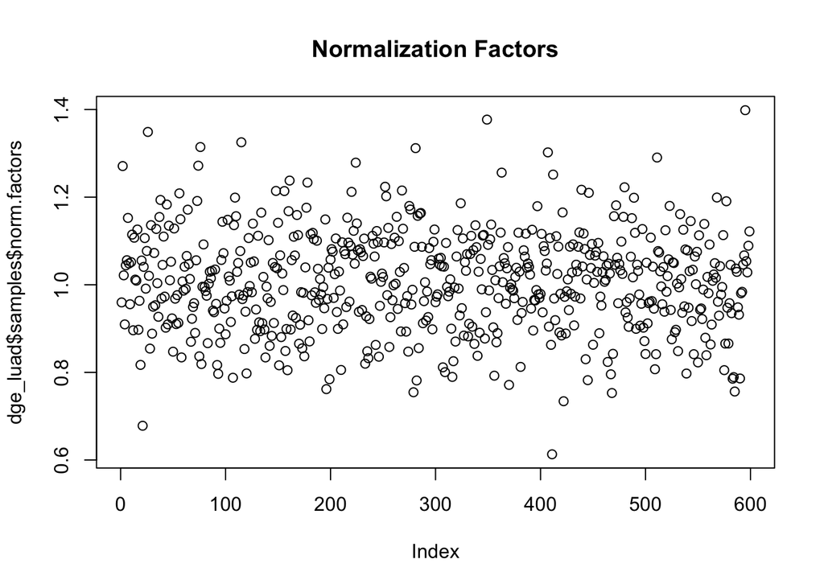

```r
library(edgeR)
library(EnhancedVolcano)

# =========================
# EdgeR con datos de LUAD
# =========================
dge_luad <- DGEList(counts = LUAD_mat_NT_TP, group = factor(luad_meta_NT_TP$shortLetterCode))
keep_luad <- filterByExpr(dge_luad)
dge1_luad <- dge_luad[keep_luad,,keep.lib.size=FALSE]

# Normalización TMM y comprobación:
dge_luad <- normLibSizes(dge1_luad,"TMM") # normalizción de datos por TMM

   ## Graficación de normalización:
plot(dge_luad$samples$norm.factors, main="Normalization Factors")
```

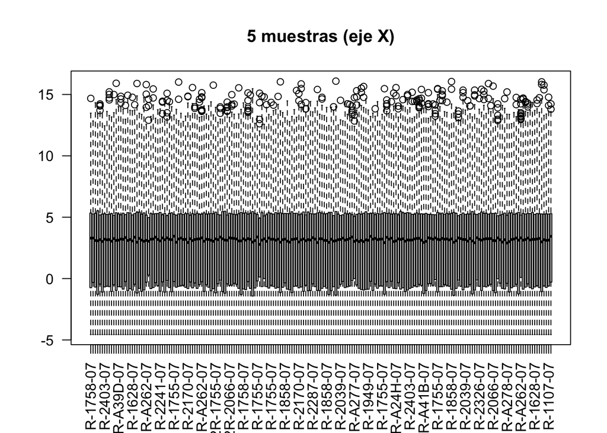

```r
boxplot(cpm(dge_luad, log=TRUE)[, 1:200],
        las = 2,
        main = "5 muestras (eje X)")
```

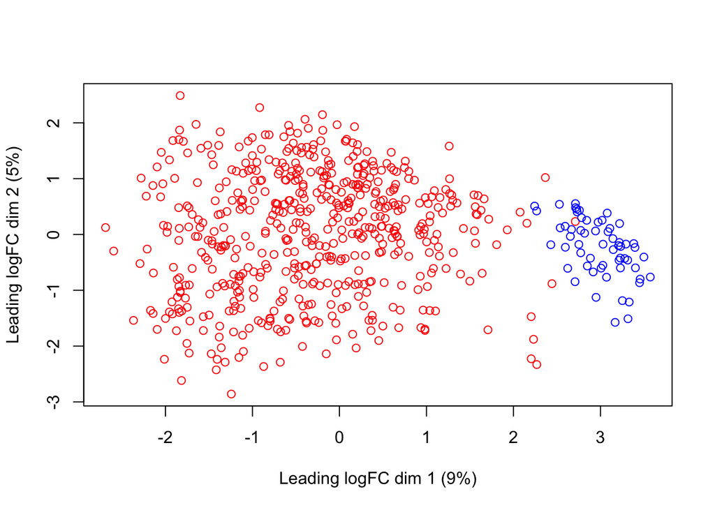

```r
# PlotMDS: Comporbar que se separen las muestras:
col_er_luad <- as.factor(dge_luad$samples$group)
levels(col_er_luad) <- c("blue","red")
col_er_luad <- as.character(col_er_luad)
plotMDS(cpm(dge_luad, log=TRUE, prior.count=1), labels=NULL, pch=1, col=col_er_luad)
```

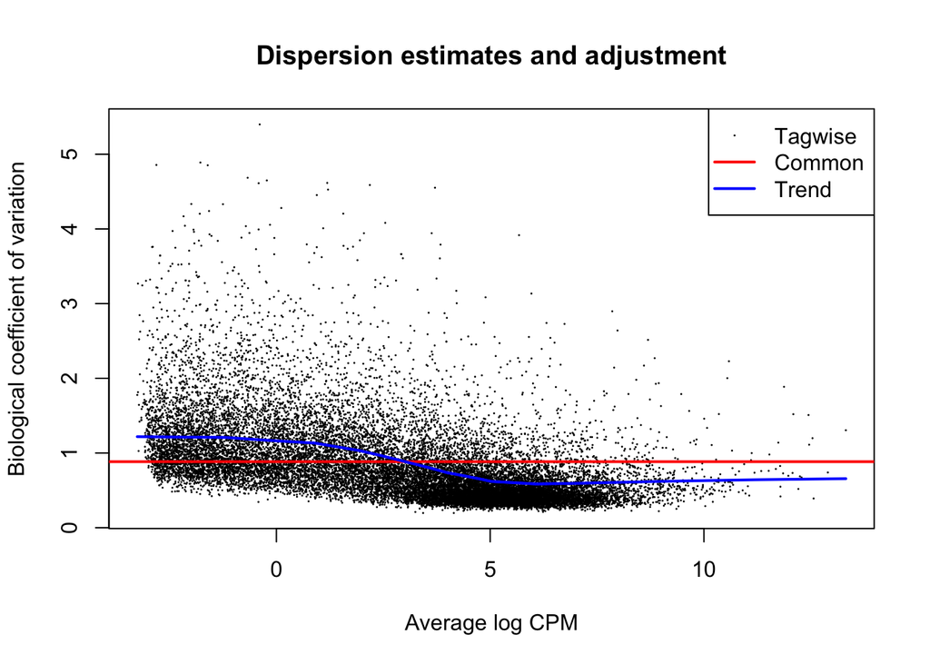

```r
# Establecer diseño del modelo:
group_luad <- factor(dge_luad$samples$group)
group_luad <- relevel(group_luad, ref="NT")
design_luad <- model.matrix(~ group_luad)


# Estimar dispersión:
dge_luad <- estimateDisp(dge_luad, design_luad)
plotBCV(dge_luad, main="Dispersion estimates and adjustment")
```

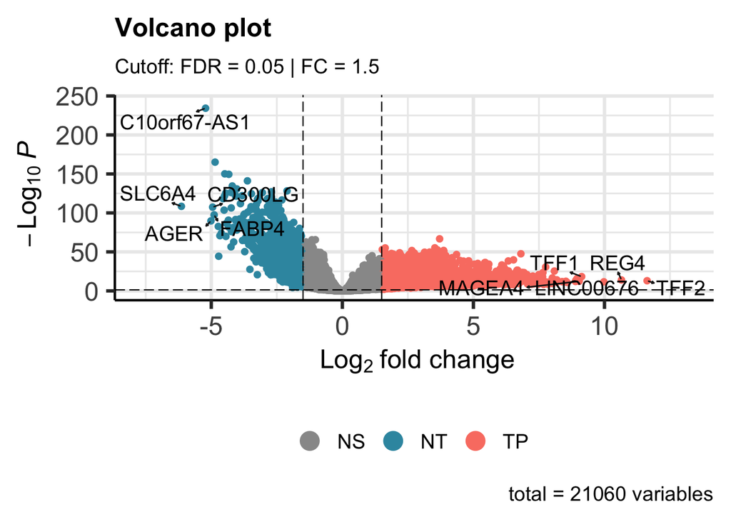

```r
# Ajustar modelo:
fit_luad <- glmQLFit(dge_luad, design_luad)
qlf_luad <- glmQLFTest(fit_luad, coef = 2) # Compara TP vs NT

# Resultados:
results_edgeR_luad <- topTags(qlf_luad, n = Inf)$table
results_edgeR_luad <- results_edgeR_luad %>%
  tibble::rownames_to_column("SYMBOL")



# =========================
# Volcano Plot LUAD (TP vs NT)
# =========================

set.seed(1234)

# 1.Seleccionar top genes up y downregulated:
top_up_luad <- results_edgeR_luad %>%
  dplyr::filter(FDR < 0.05,logFC > 1.5) %>%
  dplyr::arrange(desc(logFC)) %>%
  dplyr::slice_head(n = 5) %>%
  dplyr::pull(SYMBOL)

top_down_luad <- results_edgeR_luad %>%
  dplyr::filter(FDR < 0.05,logFC < -1.5) %>%
  dplyr::arrange(logFC) %>%
  dplyr::slice_head(n = 5) %>%
  dplyr::pull(SYMBOL)

top_genes_luad <- c(top_up_luad, top_down_luad)

# 2.EnhancedVolcano Plot:
#png("edgeRVolcanoLUAD.png")
EnhancedVolcano(results_edgeR_luad,
                lab = results_edgeR_luad$SYMBOL,
                x = 'logFC',
                y = 'FDR',
                FCcutoff = 1.5,
                pCutoff = 0.05,
                colCustom = c(
                  "NS"   = "grey60",
                  "NT" = "#3697AF",
                  "TP" = "salmon")[results_edgeR_luad %>%
                                       dplyr::mutate(group = dplyr::case_when(
                                         FDR <= 0.05 & logFC <= -1.5 ~ "NT",
                                         FDR <= 0.05 & logFC >= 1.5  ~ "TP",
                                         TRUE ~ "NS")) %>% dplyr::pull(group)],
                pointSize = 1,
                colAlpha = 1,
                drawConnectors = TRUE,
                widthConnectors = 0.5,
                legendPosition = 'bottom',
                selectLab = top_genes_luad,
                subtitle = "Cutoff: FDR = 0.05 | FC = 1.5")
```

```r
#dev.off()
```

## 6.3. EdgeR LUSC (TP vs NT):

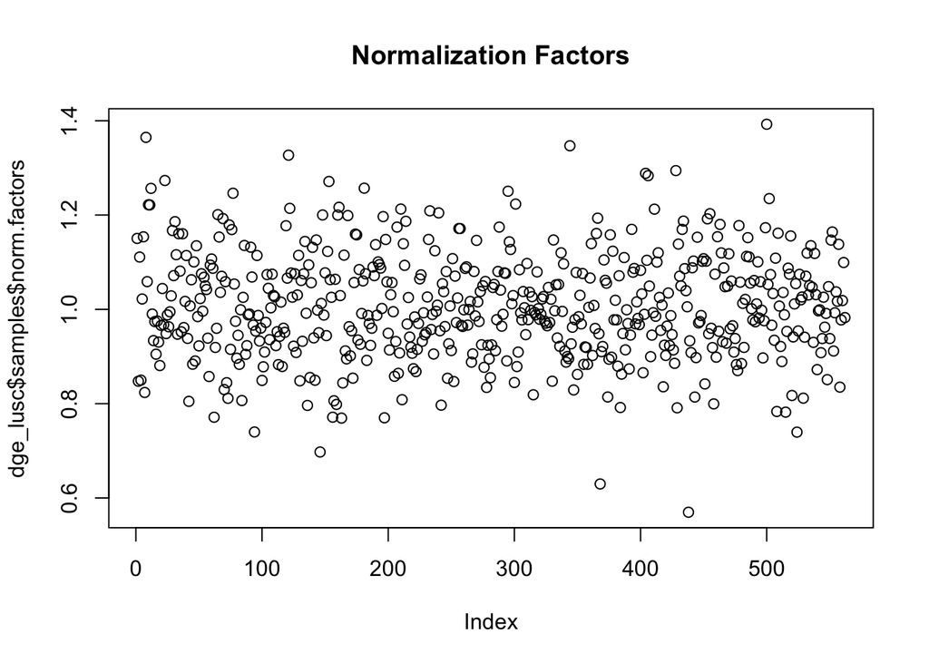

```r
# =========================
# EdgeR con datos LUSC:
# =========================

dge_lusc <- DGEList(counts = LUSC_mat_NT_TP, group = factor(lusc_meta_NT_TP$shortLetterCode))
keep_lusc <- filterByExpr(dge_lusc)
dge1_lusc <- dge_lusc[keep_lusc,,keep.lib.size=FALSE]

# Normalización TMM y comprobación:
dge_lusc <- normLibSizes(dge1_lusc,"TMM") # normalizción de datos por TMM

   ## Graficación de normalización:
plot(dge_lusc$samples$norm.factors, main="Normalization Factors")
```

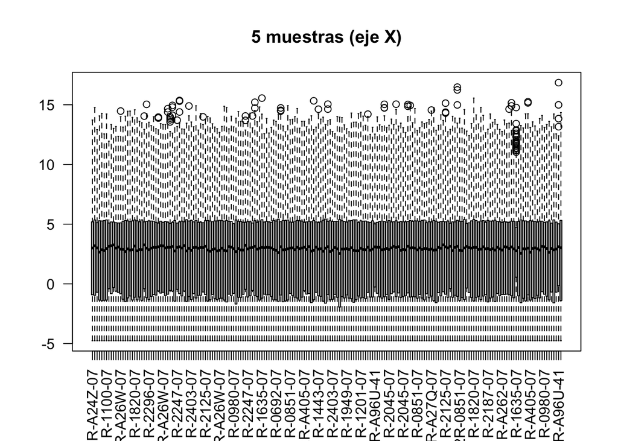

```r
boxplot(cpm(dge_lusc, log=TRUE)[, 1:200],
        las = 2,
        main = "5 muestras (eje X)")
```

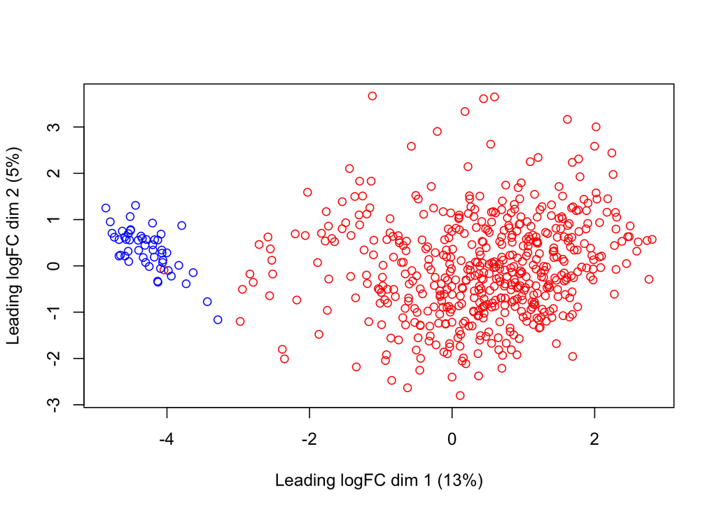

```r
# PlotMDS: Comprobar que se separen muestras
col_er_lusc <- as.factor(dge_lusc$samples$group)
levels(col_er_lusc) <- c("blue","red")
col_er_lusc <- as.character(col_er_lusc)
plotMDS(cpm(dge_lusc, log=TRUE, prior.count = 1), labels=NULL, pch=1, col=col_er_lusc)
```

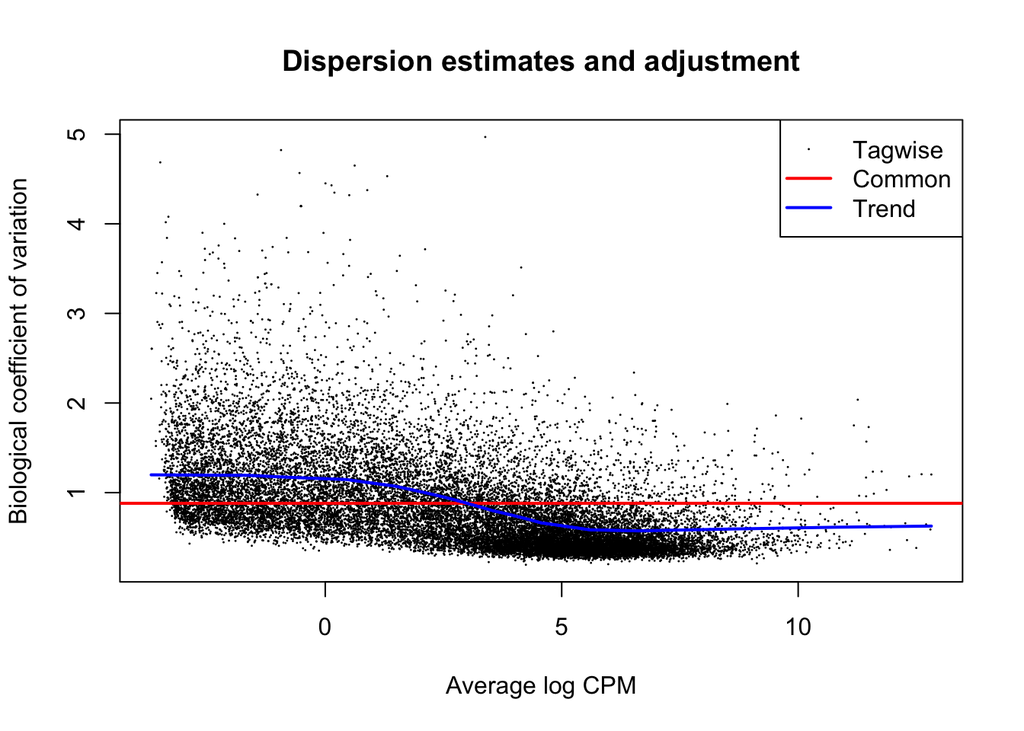

```r
# Diseño de la matriz del modelo:
group_lusc <- factor(dge_lusc$samples$group)
group_lusc <- relevel(group_lusc, ref="NT")
design_lusc <- model.matrix(~ group_lusc)

# Estimar dispersion:
dge_lusc <- estimateDisp(dge_lusc, design_lusc)
plotBCV(dge_lusc, main="Dispersion estimates and adjustment")
```

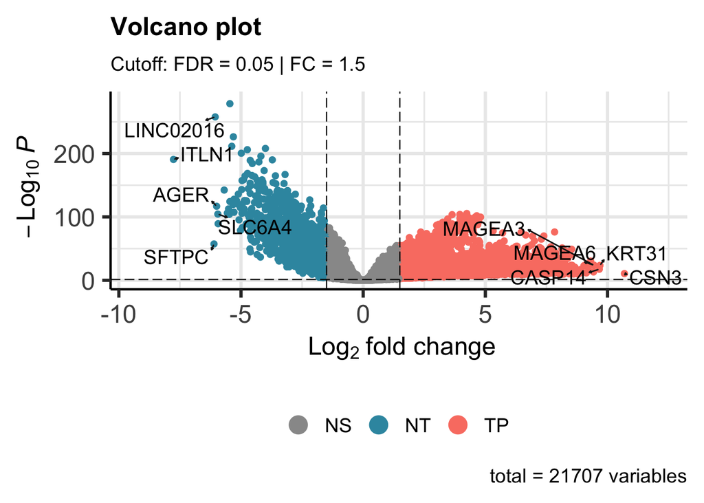

```r
# Ajustar modelo:
fit_lusc <- glmQLFit(dge_lusc, design_lusc)
qlf_lusc <- glmQLFTest(fit_lusc, coef = 2) # Compara TP vs NT

# Resultados
results_edgeR_lusc <- topTags(qlf_lusc, n = Inf)$table
results_edgeR_lusc <- results_edgeR_lusc %>%
  tibble::rownames_to_column("SYMBOL")


# =========================
# Volcano Plot LUAD (TP vs NT)
# =========================
set.seed(1234)

# 1. Extraer top genes up y downrgulated:
top_up_lusc <- results_edgeR_lusc %>%
  dplyr::filter(FDR < 0.05,logFC > 1.5) %>%
  dplyr::arrange(desc(logFC)) %>%
  dplyr::slice_head(n = 5) %>%
  dplyr::pull(SYMBOL)

top_down_lusc <- results_edgeR_lusc %>%
  dplyr::filter(FDR < 0.05,logFC < -1.5) %>%
  dplyr::arrange(logFC) %>%
  dplyr::slice_head(n = 5) %>%
  dplyr::pull(SYMBOL)

top_genes_lusc <- c(top_up_lusc, top_down_lusc)

# 2.EnhancedVolcano Plot
#png("edgeRVolcanoLUSC.png")
EnhancedVolcano(results_edgeR_lusc,
                lab = results_edgeR_lusc$SYMBOL,
                x = 'logFC',
                y = 'FDR',
                FCcutoff = 1.5,
                pCutoff = 0.05,
                colCustom = c(
                  "NS"   = "grey60",
                  "NT" = "#3697AF",
                  "TP" = "salmon")[results_edgeR_lusc %>%
                                       dplyr::mutate(group = dplyr::case_when(
                                         FDR <= 0.05 & logFC <= -1.5 ~ "NT",
                                         FDR <= 0.05 & logFC >= 1.5  ~ "TP",
                                         TRUE ~ "NS")) %>% dplyr::pull(group)],
                pointSize = 1,
                colAlpha = 1,
                drawConnectors = TRUE,
                widthConnectors = 0.5,
                legendPosition = 'bottom',
                selectLab = top_genes_lusc,
                subtitle = "Cutoff: FDR = 0.05 | FC = 1.5")
```

```r
#dev.off()
```

## 6.4. Heatmap Genes Diferencialmente Expresados:

### 6.4.1. Heatmap DEG LUSC

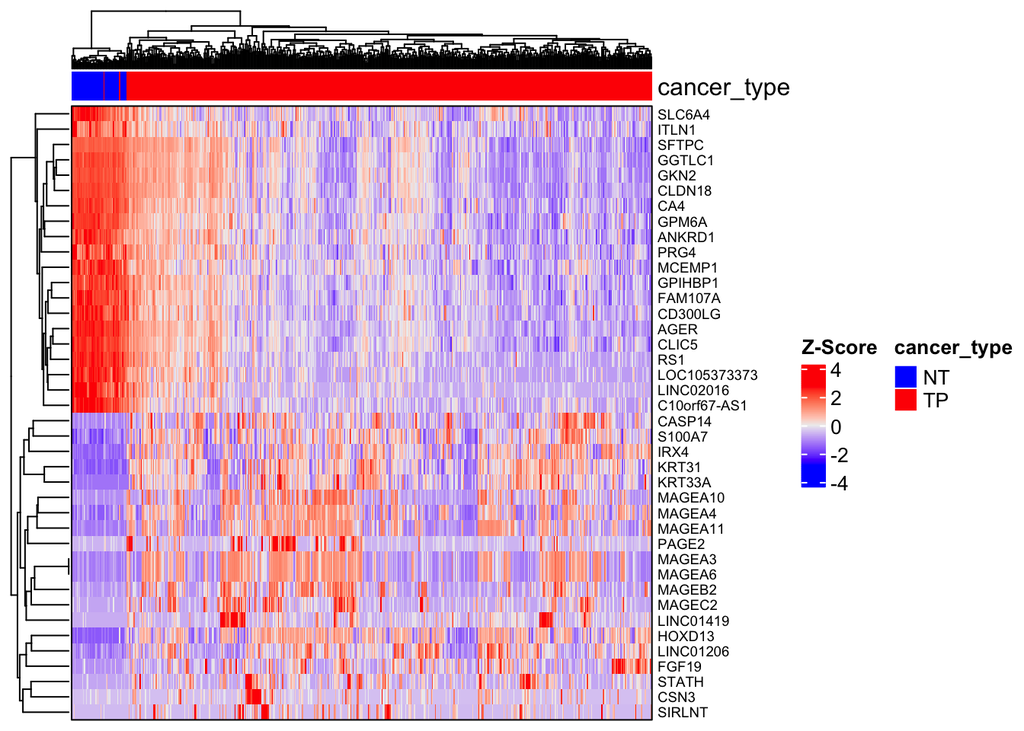

```r
conflicted::conflicts_prefer(
  dplyr::filter,
  dplyr::select,
  dplyr::mutate,
  dplyr::arrange
)
################
# HeatMap LUSC
################
# 1. Extraer top 25 genes up y downregulated:
top_LUSC_up <- results_edgeR_lusc %>%
  filter(FDR < 0.05, logFC > 1.5) %>%
  arrange(desc(logFC)) %>%
  slice_head(n = 20)

top_LUSC_down <- results_edgeR_lusc %>%
  filter(FDR < 0.05, logFC < -1.5) %>%
  arrange(logFC) %>%
  slice_head(n = 20)

selected_genes_LUSC <- rbind(top_LUSC_up, top_LUSC_down)

# 2. Normalizar a logCPM los counts:
heatmap_matrix_edge_lusc <- cpm(dge_lusc, log=TRUE, prior.count=1)[selected_genes_LUSC$SYMBOL, ]

# 3. Hacer la transversa de los datos escalados transpuestos:
heatmap_matrix_edge_lusc <- t(scale(t(heatmap_matrix_edge_lusc)))


# 4. Graficación:
library(ComplexHeatmap)
set.seed(1234)

    ## Establecer colores
ha_lusc <- HeatmapAnnotation(
  cancer_type = lusc_meta_NT_TP$shortLetterCode, col = list(cancer_type = c("TP" = "red", "NT" = "blue")))

    ##Heatmap
Heatmap(heatmap_matrix_edge_lusc,
        name = "Z-Score",
        show_column_names = FALSE,
        border = TRUE,
        row_names_gp = gpar(fontsize = 7),
        top_annotation = ha_lusc)
```

### 6.4.1. Heatmap DEG LUAD

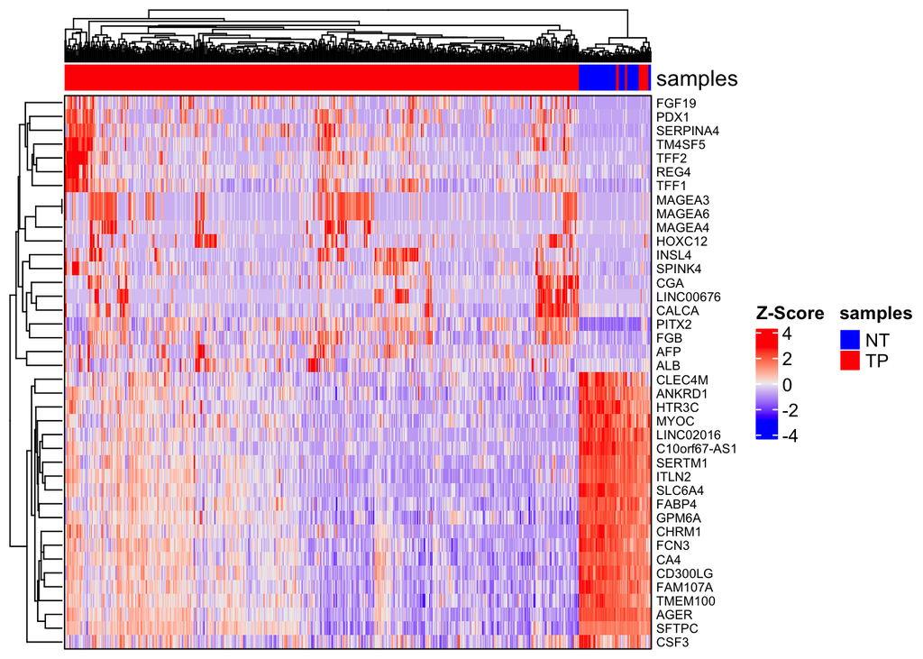

```r
################
# HeatMap LUAD
################
# 1. Extraer top 25 genes up y downregulated:
top_LUAD_up <- results_edgeR_luad %>%
  filter(FDR < 0.05,logFC > 1.5) %>%
  arrange(desc(logFC)) %>%
  slice_head(n=20)

top_LUAD_down <- results_edgeR_luad %>%
  filter(FDR < 0.05, logFC < -1.5) %>%
  arrange(logFC) %>%
  slice_head(n=20)

selected_genes_LUAD <- rbind(top_LUAD_up, top_LUAD_down)

# 2. Normalizar a logCPM los counts:
heatmap_matrix_edge_luad <- cpm(dge_luad, log=TRUE, prior.count=1)[selected_genes_LUAD$SYMBOL, ]

# 3. Hacer la transversa de los datos escalados transpuestos:
heatmap_matrix_edge_luad <- t(scale(t(heatmap_matrix_edge_luad)))

# 4. Graficación:
set.seed(1234)

    ## Establecer colores
ha_luad <- HeatmapAnnotation(
  samples = luad_meta_NT_TP$shortLetterCode, col = list(samples = c("TP" = "red", "NT" = "blue")))

    ##Heatmap
Heatmap(heatmap_matrix_edge_luad,
        name = "Z-Score",
        show_column_names = FALSE,
        border = TRUE,
        row_names_gp = gpar(fontsize = 7),
        top_annotation = ha_luad)
```

# 7. Deseq2 (Comprobación rigurosidad):

Se ha optado por la doble validación con el algoritmo Deseq2 para validar los genes up y downregulated obtenidos en cada caso con EdgeR.

## 7.1. Deseq2 LUAD:

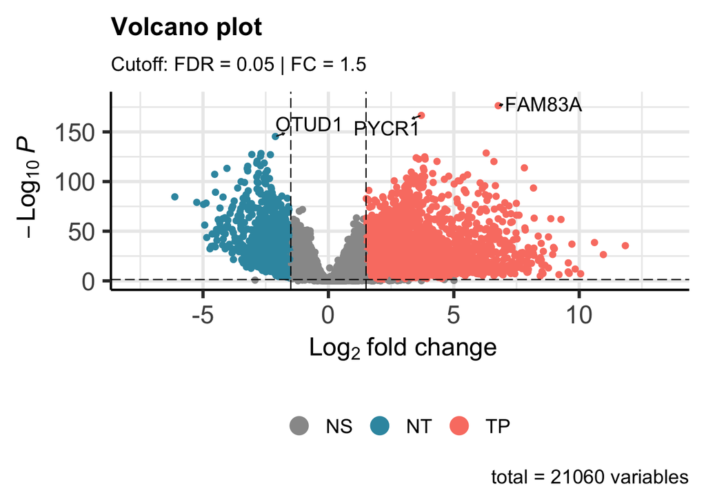

```r
###############
# Deseq2 LUAD:
###############
dds1_luad <- DESeqDataSetFromMatrix(
  countData = dge1_luad$counts,
  colData = luad_meta_NT_TP,
  design = ~ shortLetterCode
)

dds_luad <- DESeq(dds1_luad, betaPrior = FALSE)
res_luad <- results(dds_luad, contrast = c("shortLetterCode", "TP", "NT"))
res_shrunk_luad <- lfcShrink(dds_luad,
  coef = "shortLetterCode_TP_vs_NT" ,
  type = "apeglm"
)
results_deseq_luad <- as.data.frame(res_shrunk_luad) %>%
  tibble::rownames_to_column("SYMBOL")%>%
  na.omit()

##############
# VolcanoPlot LUAD
#############
library(EnhancedVolcano)
set.seed(1234)


EnhancedVolcano(results_deseq_luad,
                lab = results_deseq_luad$SYMBOL,
                x = 'log2FoldChange',
                y = 'padj',
                FCcutoff = 1.5,
                pCutoff = 0.05,
                colCustom = c(
                  "NS"   = "grey60",
                  "NT" = "#3697AF",
                  "TP" = "salmon")[results_deseq_luad %>%
                                       dplyr::mutate(group = dplyr::case_when(
                                         padj <= 0.05 & log2FoldChange <= -1.5 ~ "NT",
                                         padj <= 0.05 & log2FoldChange >= 1.5  ~ "TP",
                                         TRUE ~ "NS")) %>% dplyr::pull(group)],
                pointSize = 1,
                colAlpha = 1,
                drawConnectors = TRUE,
                widthConnectors = 0.5,
                legendPosition = 'bottom',
                subtitle = "Cutoff: FDR = 0.05 | FC = 1.5")
```

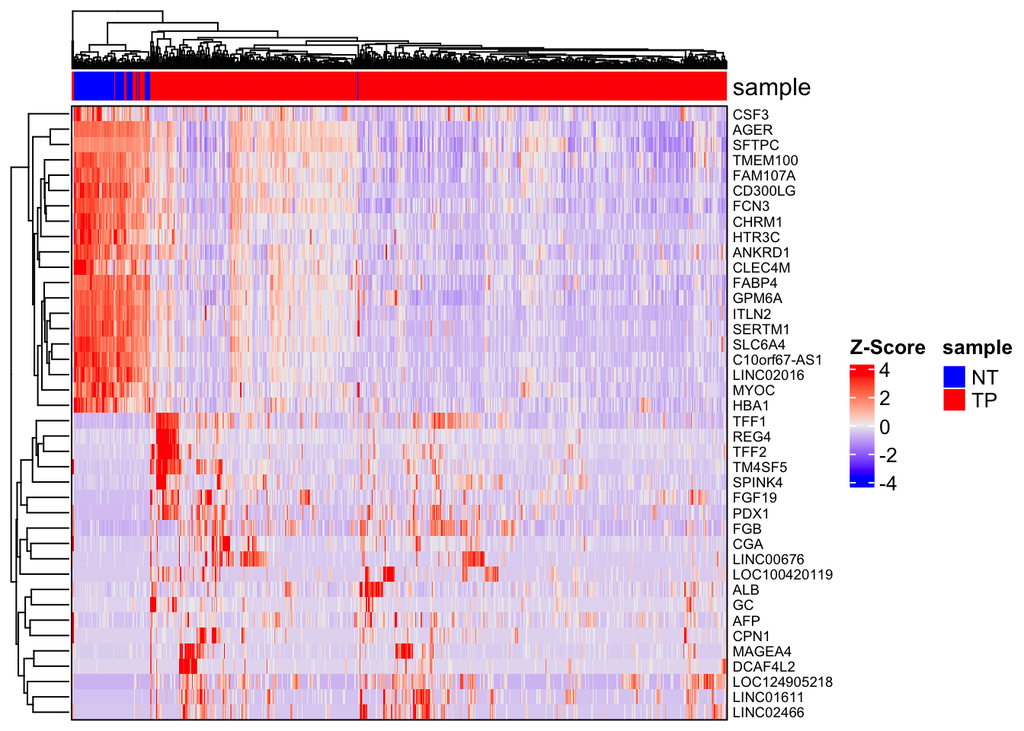

```r
###################
# Heatmap DEG LUAD:
###################
# 1. Extraer top 25 up y downregulated genes:
top_LUAD_down<- results_deseq_luad %>%
  filter(log2FoldChange < -1.5, padj < 0.05) %>%
  arrange(log2FoldChange) %>%
  head(20)
top_LUAD_up<- results_deseq_luad %>%
  filter(log2FoldChange > 1.5, padj < 0.05) %>%
  arrange(desc(log2FoldChange)) %>%
  head(20)
selected_genes_des <- rbind(top_LUAD_down, top_LUAD_up)
top_40_genes_des <- selected_genes_des$SYMBOL

# 2. Normalizar VST:
vsd_des <- vst(dds1_luad, blind = TRUE)
vsd_des <- assay(vsd_des)

# 3. Filtrar los genes up y down
heatmap_matrix_des <- vsd_des[top_40_genes_des, ]

# 4. Transpuesta de los datos escalados:
heatmap_matrix_des <- t(scale(t(heatmap_matrix_des)))

# 5. Graficación:
library(ComplexHeatmap)
set.seed(1234)

  ## Establecer colores:
ha <- HeatmapAnnotation(
  sample = luad_meta_NT_TP$shortLetterCode, col = list(sample = c("TP" = "red", "NT" = "blue"))
)

  ## Heatmap:
Heatmap(heatmap_matrix_des,
        name = "Z-Score",
        show_column_names = FALSE,
        border = TRUE,
        row_names_gp = gpar(fontsize = 7),
        top_annotation = ha)
```

## 7.2. Deseq2 LUSC

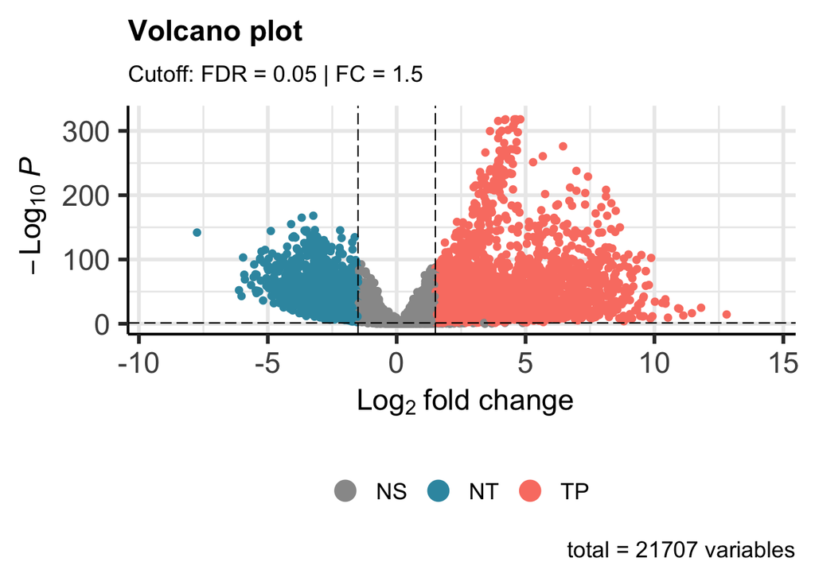

```r
###################
# DESeq2 LUSC
##################
dds1_lusc <- DESeqDataSetFromMatrix(
  countData = dge1_lusc$counts,
  colData = lusc_meta_NT_TP,
  design = ~ shortLetterCode
)

dds_lusc <- DESeq(dds1_lusc, betaPrior = FALSE)

res_lusc <- results(dds_lusc, contrast = c("shortLetterCode", "TP", "NT"))
res_shrunk_lusc <- lfcShrink(dds_lusc,
  coef = "shortLetterCode_TP_vs_NT" ,
  type = "apeglm"
)
results_deseq_lusc <- as.data.frame(res_shrunk_lusc) %>%
  tibble::rownames_to_column("SYMBOL")%>%
  na.omit()

##################
# VolcanoPlot LUSC
###################
library(EnhancedVolcano)
set.seed(1234)


EnhancedVolcano(results_deseq_lusc,
                lab = results_deseq_lusc$SYMBOL,
                x = 'log2FoldChange',
                y = 'padj',
                FCcutoff = 1.5,
                pCutoff = 0.05,
                colCustom = c(
                  "NS"   = "grey60",
                  "NT" = "#3697AF",
                  "TP" = "salmon")[results_deseq_lusc %>%
                                       dplyr::mutate(group = dplyr::case_when(
                                         padj <= 0.05 & log2FoldChange <= -1.5 ~ "NT",
                                         padj <= 0.05 & log2FoldChange >= 1.5  ~ "TP",
                                         TRUE ~ "NS")) %>% dplyr::pull(group)],
                pointSize = 1,
                colAlpha = 1,
                drawConnectors = TRUE,
                widthConnectors = 0.5,
                legendPosition = 'bottom',
                subtitle = "Cutoff: FDR = 0.05 | FC = 1.5")
```

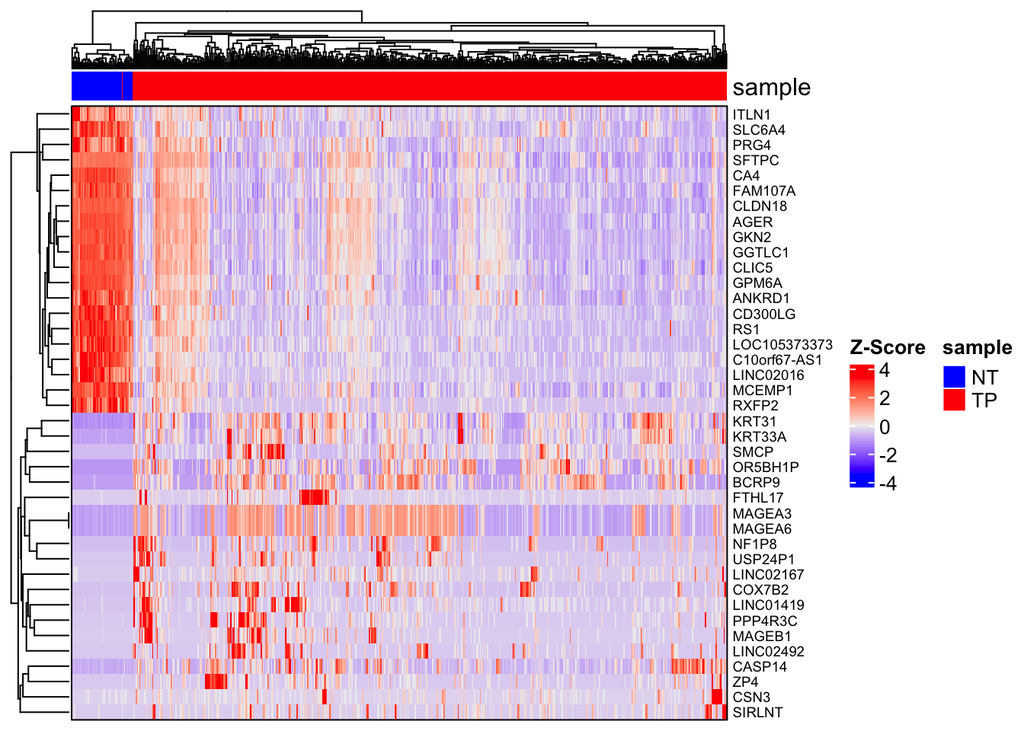

```r
###################
# HeatMap DEG LUSC
###################
# 1. Extraer top 25 up y downregulated genes:
top_LUSC_down<- results_deseq_lusc %>%
  filter(log2FoldChange < -1.5, padj < 0.05) %>%
  arrange(log2FoldChange) %>%
  head(20)
top_LUSC_up<- results_deseq_lusc %>%
  filter(log2FoldChange > 1.5, padj < 0.05) %>%
  arrange(desc(log2FoldChange)) %>%
  head(20)

selected_genes_des_lusc <- rbind(top_LUSC_up, top_LUSC_down)
top_40_genes_des_LUSC <- selected_genes_des_lusc$SYMBOL

# 2. Normalizar VST:
vsd_des_lusc <- vst(dds1_lusc, blind = TRUE)
vsd_des_lusc <- assay(vsd_des_lusc)

# 3. Filtrar los genes up y down
heatmap_matrix_des_lusc <- vsd_des_lusc[top_40_genes_des_LUSC, ]

# 4. Transpuesta de los datos escalados:
heatmap_matrix_des_lusc <- t(scale(t(heatmap_matrix_des_lusc)))

# 5. Graficación:
library(ComplexHeatmap)
set.seed(1234)

  ## Establecer colores:
ha_lusc <- HeatmapAnnotation(
  sample = lusc_meta_NT_TP$shortLetterCode, col = list(sample = c("TP" = "red", "NT" = "blue"))
)

  ## Heatmap:
Heatmap(heatmap_matrix_des_lusc,
        name = "Z-Score",
        show_column_names = FALSE,
        border = TRUE,
        row_names_gp = gpar(fontsize = 7),
        top_annotation = ha_lusc)
```

## 7.3. VennDiaram de los genes predichos por EdgeR y Deseq2:

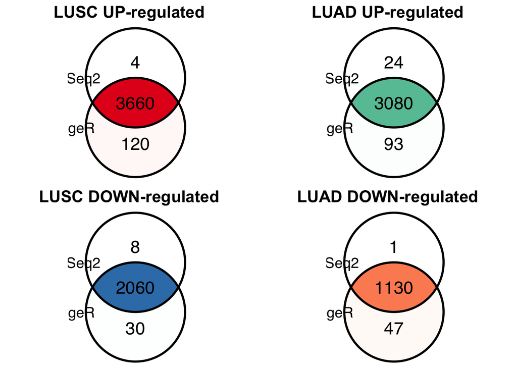

```r
# Instala y carga las librerías necesarias si no las tienes
# install.packages(c("ggVennDiagram", "ggplot2", "gridExtra", "RColorBrewer"))
library(ggVennDiagram)
library(ggplot2)
library(gridExtra)
library(RColorBrewer)

# =========================================================
# 1. GENES UP/DOWN REGULATED
# =========================================================

# -------------------------
# LUAD
# -------------------------

# edgeR
er_up_LUAD <- results_edgeR_luad %>%
  filter(FDR <= 0.05, logFC >= 1.5) %>%
  pull(SYMBOL)

er_down_LUAD <- results_edgeR_luad %>%
  filter(FDR <= 0.05, logFC <= -1.5) %>%
  pull(SYMBOL)

# DESeq2
ds_up_LUAD <- results_deseq_luad %>%
  filter(padj <= 0.05, log2FoldChange >= 1.5) %>%
  pull(SYMBOL)

ds_down_LUAD <- results_deseq_luad %>%
  filter(padj <= 0.05, log2FoldChange <= -1.5) %>%
  pull(SYMBOL)

# -------------------------
# LUSC
# -------------------------

# edgeR
er_up_LUSC <- results_edgeR_lusc %>%
  filter(FDR <= 0.05, logFC >= 1.5) %>%
  pull(SYMBOL)

er_down_LUSC <- results_edgeR_lusc %>%
  filter(FDR <= 0.05, logFC <= -1.5) %>%
  pull(SYMBOL)

# DESeq2
ds_up_LUSC <- results_deseq_lusc %>%
  filter(padj <= 0.05, log2FoldChange >= 1.5) %>%
  pull(SYMBOL)

ds_down_LUSC <- results_deseq_lusc %>%
  filter(padj <= 0.05, log2FoldChange <= -1.5) %>%
  pull(SYMBOL)

# =========================================================
# 2. LISTAS PARA VENN
# =========================================================

# UP genes
lista_lusc_up <- list(
  edgeR = er_up_LUSC,
  DESeq2 = ds_up_LUSC
)

lista_luad_up <- list(
  edgeR = er_up_LUAD,
  DESeq2 = ds_up_LUAD
)

# DOWN genes
lista_lusc_down <- list(
  edgeR = er_down_LUSC,
  DESeq2 = ds_down_LUSC
)

lista_luad_down <- list(
  edgeR = er_down_LUAD,
  DESeq2 = ds_down_LUAD
)

# =========================================================
# 3. PALETAS DE COLORES
# =========================================================

colores_lusc <- brewer.pal(3, "Set1")[1:2]
colores_luad <- brewer.pal(3, "Set2")[1:2]

# =========================================================
# 4. VENN LUSC UP
# =========================================================

p1 <- ggVennDiagram(
  lista_lusc_up,
  label = "count",
  label_alpha = 0,
  label_size = 6,
  category.names = c("edgeR", "DESeq2"),
  set_size = 5
) +
  scale_fill_gradient(
    low = "white",
    high = colores_lusc[1]
  ) +
  theme_void() +
  theme(
    legend.position = "none",
    plot.title = element_text(
      hjust = 0.5,
      size = 16,
      face = "bold"
    )
  ) +
  labs(title = "LUSC UP-regulated")

# =========================================================
# 5. VENN LUAD UP
# =========================================================

p2 <- ggVennDiagram(
  lista_luad_up,
  label = "count",
  label_alpha = 0,
  label_size = 6,
  category.names = c("edgeR", "DESeq2"),
  set_size = 5
) +
  scale_fill_gradient(
    low = "white",
    high = colores_luad[1]
  ) +
  theme_void() +
  theme(
    legend.position = "none",
    plot.title = element_text(
      hjust = 0.5,
      size = 16,
      face = "bold"
    )
  ) +
  labs(title = "LUAD UP-regulated")

# =========================================================
# 6. VENN LUSC DOWN
# =========================================================

p3 <- ggVennDiagram(
  lista_lusc_down,
  label = "count",
  label_alpha = 0,
  label_size = 6,
  category.names = c("edgeR", "DESeq2"),
  set_size = 5
) +
  scale_fill_gradient(
    low = "white",
    high = colores_lusc[2]
  ) +
  theme_void() +
  theme(
    legend.position = "none",
    plot.title = element_text(
      hjust = 0.5,
      size = 16,
      face = "bold"
    )
  ) +
  labs(title = "LUSC DOWN-regulated")

# =========================================================
# 7. VENN LUAD DOWN
# =========================================================

p4 <- ggVennDiagram(
  lista_luad_down,
  label = "count",
  label_alpha = 0,
  label_size = 6,
  category.names = c("edgeR", "DESeq2"),
  set_size = 5
) +
  scale_fill_gradient(
    low = "white",
    high = colores_luad[2]
  ) +
  theme_void() +
  theme(
    legend.position = "none",
    plot.title = element_text(
      hjust = 0.5,
      size = 16,
      face = "bold"
    )
  ) +
  labs(title = "LUAD DOWN-regulated")

# =========================================================
# 8. PANEL FINAL
# =========================================================

grid.arrange(
  p1, p2,
  p3, p4,
  ncol = 2
)
```

# 8. GSEA

## 8.1. GSEA LUAD (KEGG, Hallmark, Reactome):

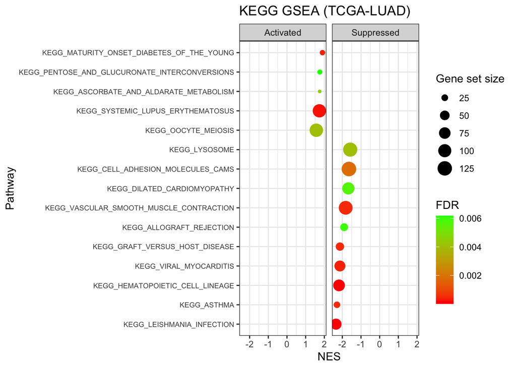

```r
library(msigdbr)
library(clusterProfiler)
library(dplyr)
library(ggplot2)
library(conflicted)

# evitar conflictos de funciones
conflict_prefer("select", "dplyr")
conflict_prefer("filter", "dplyr")
conflict_prefer("mutate", "dplyr")
conflict_prefer("arrange", "dplyr")

#################################################
# 1. GENE LIST (SYMBOL)
#################################################

df_edgeR_luad <- results_edgeR_luad

# ranking directo en SYMBOL
gene_list_luad <- df_edgeR_luad$logFC
names(gene_list_luad) <- df_edgeR_luad$SYMBOL

# limpieza
gene_list_luad <- na.omit(gene_list_luad)

# ordenar (clave para GSEA)
gene_list_luad <- sort(gene_list_luad, decreasing = TRUE)

#################################################
# 2. KEGG GSEA (SYMBOL)
#################################################

m_kegg_symbol <- msigdbr(
  species = "Homo sapiens",
  category = "C2",
  subcategory = "CP:KEGG_LEGACY"
) %>%
  dplyr::select(gs_name, gene_symbol)

gsea_kegg_luad <- GSEA(
  geneList = gene_list_luad,
  TERM2GENE = m_kegg_symbol,
  pvalueCutoff = 0.05,
  minGSSize = 10,
  maxGSSize = 500,
  seed = 1234,
  verbose = FALSE,
  pAdjustMethod = "BH"
)

df_kegg <- as.data.frame(gsea_kegg_luad) %>%
  mutate(Direction = ifelse(NES > 0, "Activated", "Suppressed")) %>%
  arrange(p.adjust)

top30_kegg <- df_kegg %>%
  slice_head(n = 15)

ggplot(top30_kegg,
       aes(x = NES,
           y = reorder(Description, NES),
           size = setSize,
           color = p.adjust)) +
  geom_point() +
  facet_grid(. ~ Direction, scales = "free_y") +
  scale_color_gradient(low = "red", high = "green") +
  theme_bw() +
  labs(title = "KEGG GSEA (TCGA-LUAD)",
       x = "NES",
       y = "Pathway",
       size = "Gene set size",
       color = "FDR") +
  theme(axis.text.y = element_text(size = 7))
```

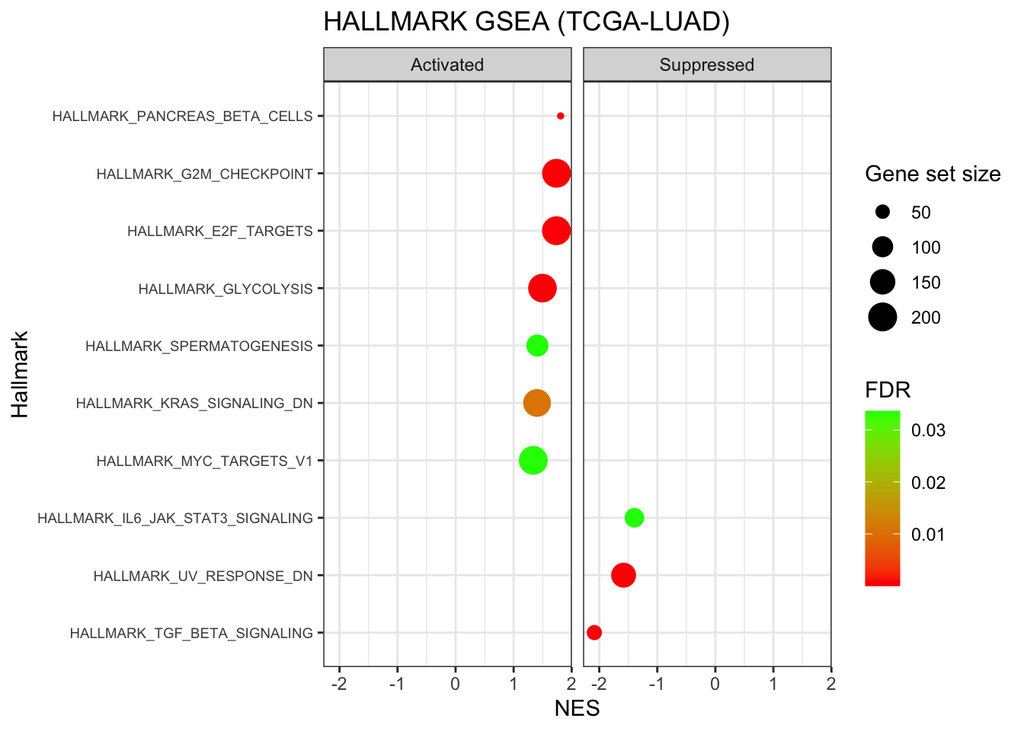

```r
#################################################
# 3. HALLMARK GSEA (SYMBOL)
#################################################

m_hall_symbol <- msigdbr(
  species = "Homo sapiens",
  category = "H"
) %>%
  dplyr::select(gs_name, gene_symbol)

gsea_hall_luad <- GSEA(
  geneList = gene_list_luad,
  TERM2GENE = m_hall_symbol,
  pvalueCutoff = 0.05,
  minGSSize = 10,
  maxGSSize = 500,
  seed = 1234,
  verbose = FALSE,
  pAdjustMethod = "BH"
)

df_hall <- as.data.frame(gsea_hall_luad) %>%
  mutate(Direction = ifelse(NES > 0, "Activated", "Suppressed")) %>%
  arrange(p.adjust)

top30_hall <- df_hall %>%
  slice_head(n = 15)

ggplot(top30_hall,
       aes(x = NES,
           y = reorder(Description, NES),
           size = setSize,
           color = p.adjust)) +
  geom_point() +
  facet_grid(. ~ Direction, scales = "free_y") +
  scale_color_gradient(low = "red", high = "green") +
  theme_bw() +
  labs(title = "HALLMARK GSEA (TCGA-LUAD)",
       x = "NES",
       y = "Hallmark",
       size = "Gene set size",
       color = "FDR") +
  theme(axis.text.y = element_text(size = 7))
```

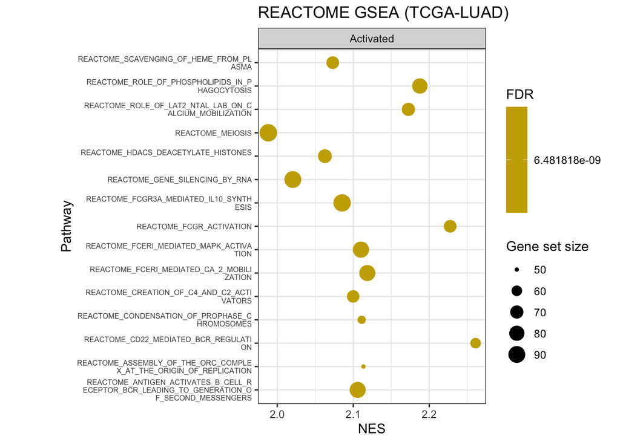

```r
#################################################
# 4. REACTOME GSEA (SYMBOL)
#################################################

m_reactome_symbol <- msigdbr(
  species = "Homo sapiens",
  category = "C2",
  subcategory = "CP:REACTOME"
) %>%
  dplyr::select(gs_name, gene_symbol)

gsea_reactome_luad <- GSEA(
  geneList = gene_list_luad,
  TERM2GENE = m_reactome_symbol,
  pvalueCutoff = 0.05,
  seed = 2022,
  minGSSize = 10,
  maxGSSize = 800,
  verbose = FALSE,
   pAdjustMethod = "BH"
)

df_reactome <- as.data.frame(gsea_reactome_luad) %>%
  mutate(Direction = ifelse(NES > 0, "Activated", "Suppressed")) %>%
  arrange(p.adjust)

top30_reactome <- df_reactome %>%
  slice_head(n = 15) %>%
  mutate(
    Description = as.character(Description),
    Description = gsub("(.{35})", "\\1\n", Description)
  )

ggplot(top30_reactome,
       aes(x = NES,
           y = Description,
           size = setSize,
           color = p.adjust)) +
  geom_point() +
  facet_grid(. ~ Direction) +
  scale_color_gradient(low = "green", high = "red") +
  theme_bw() +
  labs(title = "REACTOME GSEA (TCGA-LUAD)",
       x = "NES",
       y = "Pathway",
       size = "Gene set size",
       color = "FDR") +
  theme(axis.text.y = element_text(size = 6),
        plot.margin = margin(5, 10, 5, 50))
```

## 8.2. GSEA LUSC (KEGG, Hallmark, Reactome):

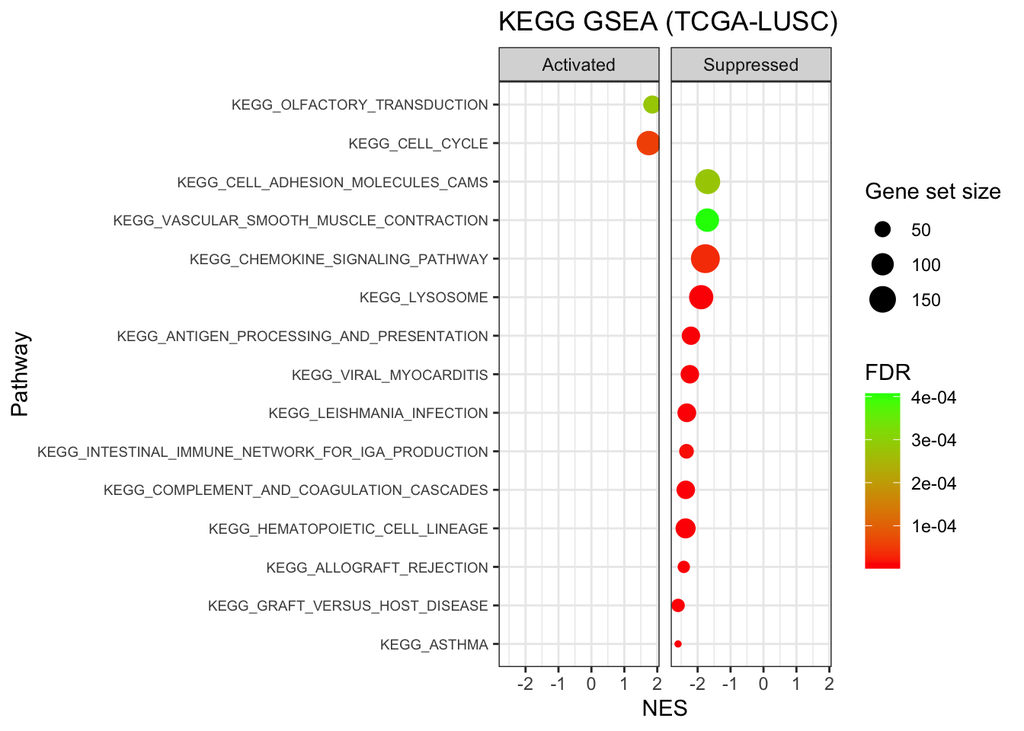

```r
library(msigdbr)
library(clusterProfiler)
library(dplyr)
library(ggplot2)
library(conflicted)

# evitar conflictos
conflict_prefer("select", "dplyr")
conflict_prefer("filter", "dplyr")
conflict_prefer("mutate", "dplyr")
conflict_prefer("arrange", "dplyr")

#################################################
# 1. GENE LIST (SYMBOL - CONSISTENTE)
#################################################

df_edgeR_lusc <- results_edgeR_lusc

# Ranking directo en SYMBOL
gene_list_lusc <- df_edgeR_lusc$logFC
names(gene_list_lusc) <- df_edgeR_lusc$SYMBOL

# limpiar NA (solo por seguridad)
gene_list_lusc <- na.omit(gene_list_lusc)

# ordenar
gene_list_lusc <- sort(gene_list_lusc, decreasing = TRUE)

#################################################
# 2. KEGG GSEA (SYMBOL)
#################################################

m_kegg_symbol <- msigdbr(
  species = "Homo sapiens",
  category = "C2",
  subcategory = "CP:KEGG_LEGACY"
) %>%
  dplyr::select(gs_name, gene_symbol)

gsea_kegg_lusc <- GSEA(
  geneList = gene_list_lusc,
  TERM2GENE = m_kegg_symbol,
  pvalueCutoff = 0.05,
  minGSSize = 10,
  maxGSSize = 500,
  seed = 1234,
  verbose = FALSE,
  pAdjustMethod = "BH"
)

df_kegg <- as.data.frame(gsea_kegg_lusc) %>%
  mutate(Direction = ifelse(NES > 0, "Activated", "Suppressed")) %>%
  arrange(p.adjust)

top30_kegg <- df_kegg %>%
  slice_head(n = 15)

ggplot(top30_kegg,
       aes(x = NES,
           y = reorder(Description, NES),
           size = setSize,
           color = p.adjust)) +
  geom_point() +
  facet_grid(. ~ Direction, scales = "free_y") +
  scale_color_gradient(low = "red", high = "green") +
  theme_bw() +
  labs(title = "KEGG GSEA (TCGA-LUSC)",
       x = "NES",
       y = "Pathway",
       size = "Gene set size",
       color = "FDR") +
  theme(axis.text.y = element_text(size = 7))
```

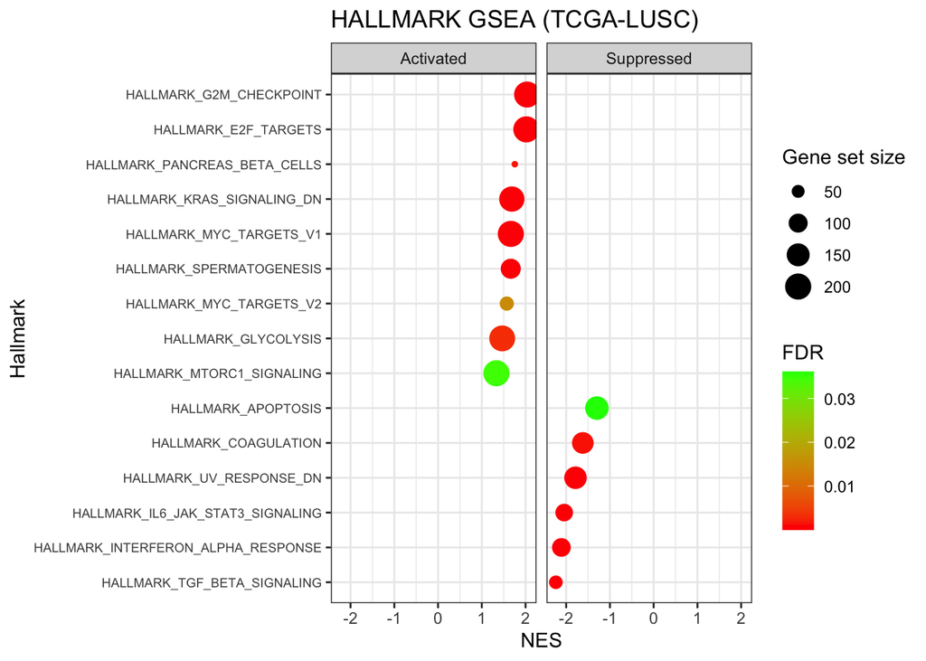

```r
#################################################
# 3. HALLMARK (SYMBOL)
#################################################

m_hall_symbol <- msigdbr(
  species = "Homo sapiens",
  category = "H"
) %>%
  dplyr::select(gs_name, gene_symbol)

gsea_hall_lusc <- GSEA(
  geneList = gene_list_lusc,
  TERM2GENE = m_hall_symbol,
  pvalueCutoff = 0.05,
  minGSSize = 10,
  maxGSSize = 500,
  seed = 1234,
  verbose = FALSE,
  pAdjustMethod = "BH"
)

df_hall <- as.data.frame(gsea_hall_lusc) %>%
  mutate(Direction = ifelse(NES > 0, "Activated", "Suppressed")) %>%
  arrange(p.adjust)

top30_hall <- df_hall %>%
  slice_head(n = 15)

ggplot(top30_hall,
       aes(x = NES,
           y = reorder(Description, NES),
           size = setSize,
           color = p.adjust)) +
  geom_point() +
  facet_grid(. ~ Direction, scales = "free_y") +
  scale_color_gradient(low = "red", high = "green") +
  theme_bw() +
  labs(title = "HALLMARK GSEA (TCGA-LUSC)",
       x = "NES",
       y = "Hallmark",
       size = "Gene set size",
       color = "FDR") +
  theme(axis.text.y = element_text(size = 7))
```

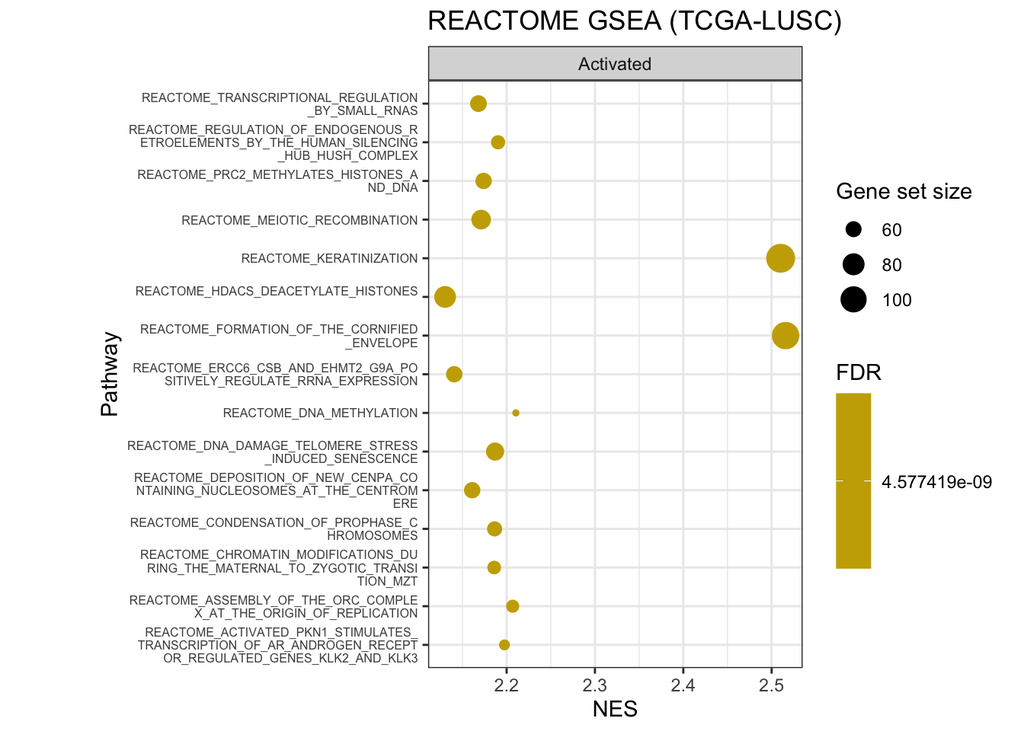

```r
#################################################
# 4. REACTOME (SYMBOL)
#################################################

m_reactome_symbol <- msigdbr(
  species = "Homo sapiens",
  category = "C2",
  subcategory = "CP:REACTOME"
) %>%
  dplyr::select(gs_name, gene_symbol)

gsea_reactome_lusc <- GSEA(
  geneList = gene_list_lusc,
  TERM2GENE = m_reactome_symbol,
  pvalueCutoff = 0.05,
  seed = 2022,
  minGSSize = 10,
  maxGSSize = 800,
  verbose = FALSE,
  pAdjustMethod = "BH"
)

df_reactome <- as.data.frame(gsea_reactome_lusc) %>%
  mutate(Direction = ifelse(NES > 0, "Activated", "Suppressed")) %>%
  arrange(p.adjust)

top30_reactome <- df_reactome %>%
  slice_head(n = 15) %>%
  mutate(
    Description = as.character(Description),
    Description = gsub("(.{35})", "\\1\n", Description)
  )

ggplot(top30_reactome,
       aes(x = NES,
           y = Description,
           size = setSize,
           color = p.adjust)) +
  geom_point() +
  facet_grid(. ~ Direction) +
  scale_color_gradient(low = "green", high = "red") +
  theme_bw() +
  labs(title = "REACTOME GSEA (TCGA-LUSC)",
       x = "NES",
       y = "Pathway",
       size = "Gene set size",
       color = "FDR") +
  theme(axis.text.y = element_text(size = 6),
        plot.margin = margin(5, 10, 5, 50))
```

### 8.2.1.GO BP, CC, M LUSC

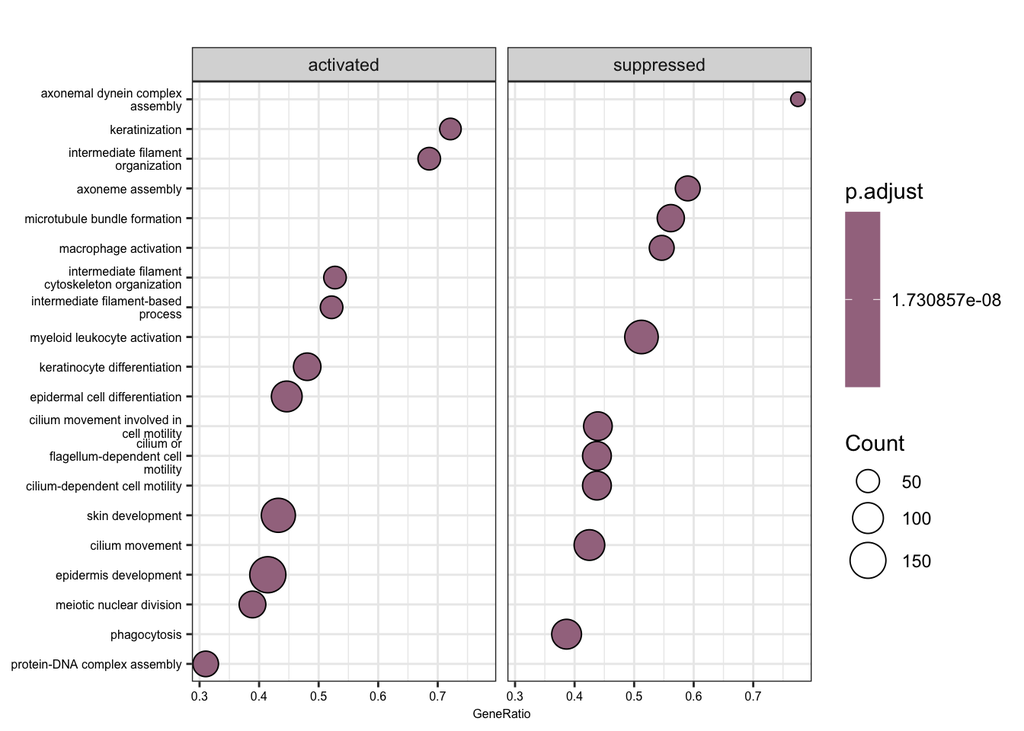

```r
## GO:

####### BP:
gse_GO_bp_lusc <- gseGO(geneList = gene_list_lusc,
                ont = "BP",
                OrgDb = org.Hs.eg.db,
                minGSSize = 10,
                maxGSSize = 500,
                keyType = "SYMBOL",
                pvalueCutoff = 0.05,
                pAdjustMethod = "BH")


dotplot(gse_GO_bp_lusc, split = ".sign",font.size= 6) +
  facet_grid(. ~ .sign)
```

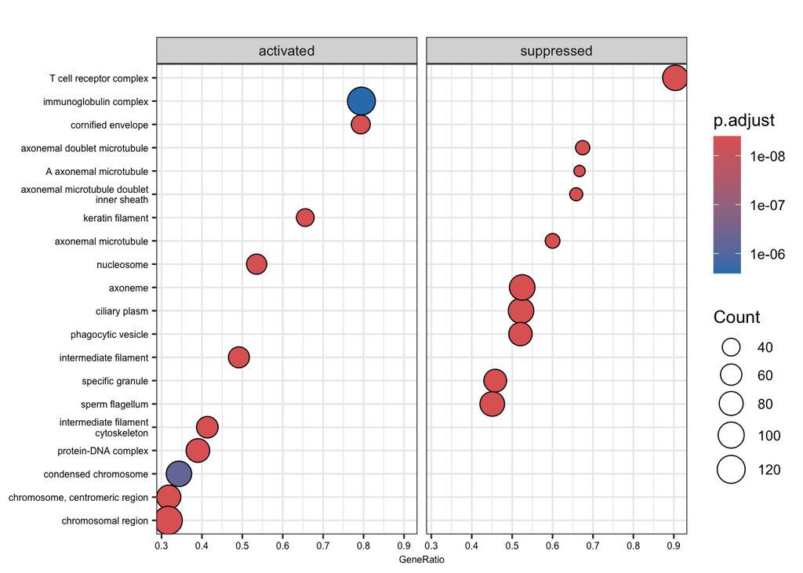

```r
###### CCs:
gse_GO_cc_lusc <- gseGO(geneList = gene_list_lusc,
                ont = "CC",
                OrgDb = org.Hs.eg.db,
                minGSSize = 10,
                maxGSSize = 500,
                keyType = "SYMBOL",
                pvalueCutoff = 0.05,
                pAdjustMethod = "BH")

dotplot(gse_GO_cc_lusc, split = ".sign",font.size= 6) +
  facet_grid(. ~ .sign)
```

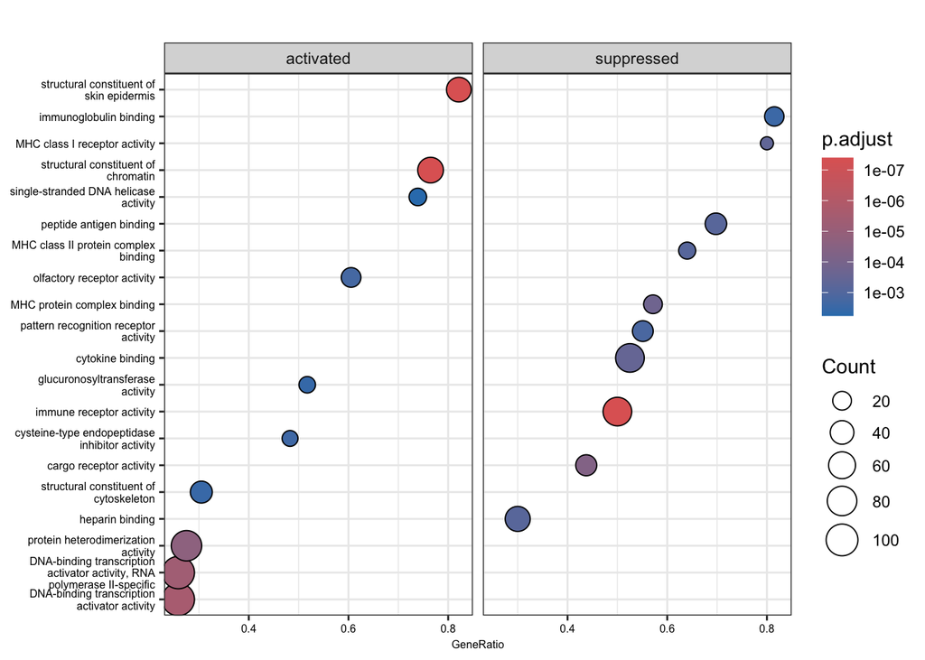

```r
##### MFs:
gse_GO_mf_lusc <- gseGO(geneList = gene_list_lusc,
                ont = "MF",
                OrgDb = org.Hs.eg.db,
                minGSSize = 10,
                maxGSSize = 500,
                keyType = "SYMBOL",
                pvalueCutoff = 0.05,
                pAdjustMethod = "BH")

dotplot(gse_GO_mf_lusc, split = ".sign",font.size= 6) +
  facet_grid(. ~ .sign)
```

# 9. DEG estratificado MUT vs WT:

## 9.1. Preparación datos:

Importamos los datos de los barcodes muestrales con sus columnas categóricas (status) para cada gen, si este está o no mutado (MUT, WT). Dado que este último documento contiene el estado del gen, mutado o no, se utilizará como metadata, y la matriz de expresión filtrada por las muestras biológicas comunes, como matriz de conteos.

```r
# Cargams los datos de genes driver detectados con muestras mutadas y wt:

################
# Genes LUAD
################

luad_mut_wt_matrix <- read.csv("/Users/noegragerajimenez/Documents/TFM/Analysis RStudio/Scripts/Análisis mutacional/plots_mut_analisis/LUAD_mut_wt_matrix.csv", stringsAsFactors = FALSE)
luad_mut_wt <- as.data.frame(luad_mut_wt_matrix)


################
# Genes LUSC
################

lusc_mut_wt_matrix <- read.csv("/Users/noegragerajimenez/Documents/TFM/Analysis RStudio/Scripts/Análisis mutacional/plots_mut_analisis/LUSC_mut_wt_matrix.csv", stringsAsFactors = FALSE)
lusc_mut_wt <- as.data.frame(lusc_mut_wt_matrix)
```

## 9.2. Función general EdgeR:

Primero de todo, para facilitar y agilizar el proceso de análisi de genes diferencialmente expresados, se ha utilizado el pipeline de EdgeR, para crear una función que establezca el codigo para realizar DEGs con EdgeR, y como output de los resultados estadísticos para cada gen. Al ser una función al que se le debe de aplicar el status del gen en concreto (columna del gen en metadata), permite que este codigo aplique los grupos en función de cada gen a estudiar, y sea reproducible.

```r
#Función edgeR
run_edger_deg <- function(expr_mat, meta, status_col) {

  # 1. grupo
  group <- factor(meta[[status_col]])

  # 2. diseño

  # 3. DGE object
  dge <- DGEList(counts = expr_mat, group=group)

  # 4. filtrado expresión baja
  keep <- filterByExpr(dge)
  dge <- dge[keep, , keep.lib.sizes = FALSE]

  # 5. normalización
  dge <- normLibSizes(dge,"TMM")

  # 6. dispersión
  group <- relevel(group, ref="WT")
  design <- model.matrix(~group)
  dge <- estimateDisp(dge, design)

  # 7. modelo
  fit <- glmQLFit(dge, design)

  # 8. contraste MUT vs WT
  qlf <- glmQLFTest(fit, coef = 2)

  # 9. resultados
  res <- topTags(qlf, n = Inf)$table
  res <- res %>%
  tibble::rownames_to_column("SYMBOL")

  return(res)

}
```

## 9.3. DEG estratificado drivers LUAD:

### 9.3.1. Unificar muestras mutadas y wt, con las del estudio de expresión:

Dado que el Tumor_Sample_Barcode no coincide por proceder de diferentes métodos, estos se han normalizado a los 16 primeros digitos,para garantizar el apareamiento. Este barcode reducido corresponde al identificador de la muestra biológica.

```r
library(edgeR)
conflicted::conflicts_prefer(base::intersect)
# 1. Extraer 16 digitos de samples en cada data:
luad_mut_wt$barcode_short <- substr(luad_mut_wt$Tumor_Sample_Barcode, 1, 16)

colnames(LUAD_mat) <- substr(colnames(LUAD_mat), 1, 16)

# 2.Ver que muestras coiciden de cada data:
common_samples <- intersect(colnames(LUAD_mat), luad_mut_wt$barcode_short)

# Filtrar cada data:
LUAD_mat_driv <- LUAD_mat[,common_samples, drop=FALSE]

luad_meta_driv <- luad_mut_wt[luad_mut_wt$barcode_short %in% common_samples, ]
luad_meta_driv <- luad_meta_driv[match(common_samples, luad_meta_driv$barcode_short), ]
LUAD_mat_driv <- LUAD_mat_driv[, luad_meta_driv$barcode_short]
```

### 9.3.2. EdgeR genes driver (mut vs wt) y GSEA Hallmarc LUAD:

Se ha realizado el EdgeR sobre la matriz de expresión de muestras TP, para ver el efecto de mut y wt en el tumor.

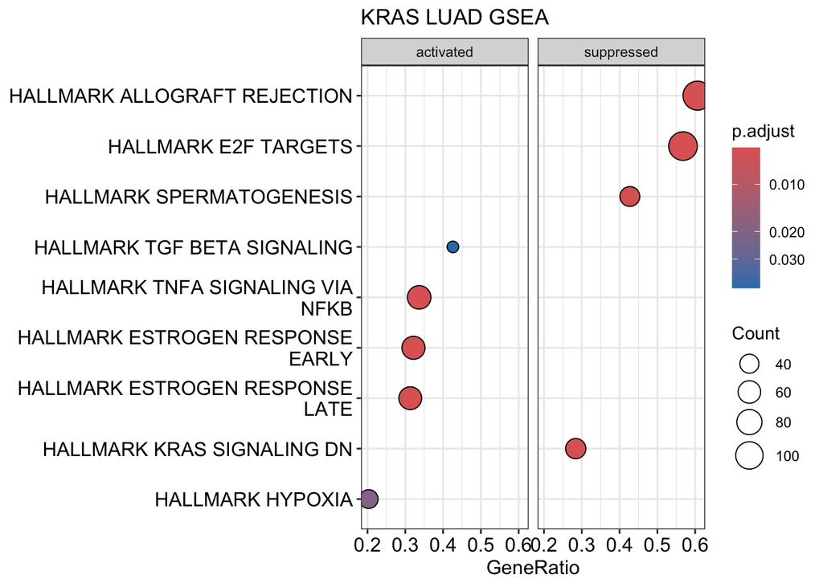

```r
library(clusterProfiler)
################
# KRAS
################
set.seed(1234)
res_KRAS <- run_edger_deg(
  expr_mat = LUAD_mat_driv,
  meta = luad_meta_driv,
  status_col = "KRAS_status"
)

gene_list_KRAS <- res_KRAS$logFC
names(gene_list_KRAS) <- res_KRAS$SYMBOL
gene_list_KRAS<- sort(gene_list_KRAS, decreasing = TRUE)

msig_res_hall_KRAS <- GSEA(geneList = gene_list_KRAS,
                 TERM2GENE = m_hall_symbol,
                 pvalueCutoff = 0.05,
                 minGSSize = 10,
                 maxGSSize = 500,
                 nPerm = 10000,
                 pAdjustMethod = "BH")



dotplot(msig_res_hall_KRAS, split = ".sign", title="KRAS LUAD GSEA") +
  facet_grid(. ~ .sign)
```

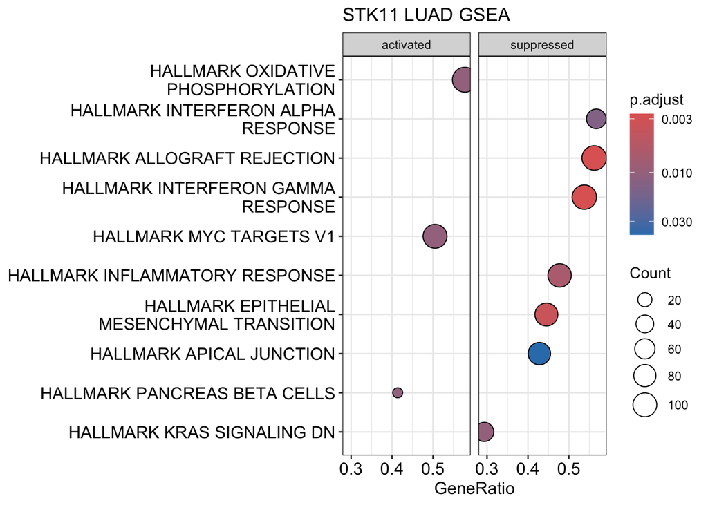

```r
################
# STK11
################
set.seed(1234)

res_STK11 <- run_edger_deg(
  expr_mat = LUAD_mat_driv,
  meta = luad_meta_driv,
  status_col = "STK11_status"
)


gene_list_STK11 <- res_STK11$logFC
names(gene_list_STK11) <- res_STK11$SYMBOL
gene_list_STK11<- sort(gene_list_STK11, decreasing = TRUE)

msig_res_hall_STK11 <- GSEA(geneList = gene_list_STK11,
                 TERM2GENE = m_hall_symbol,
                 pvalueCutoff = 0.05,
                 minGSSize = 10,
                 maxGSSize = 800,
                 nPerm = 10000,
                 pAdjustMethod = "BH")


dotplot(msig_res_hall_STK11, showCategory = 10, split = ".sign",title="STK11 LUAD GSEA") +
  facet_grid(. ~ .sign)
```

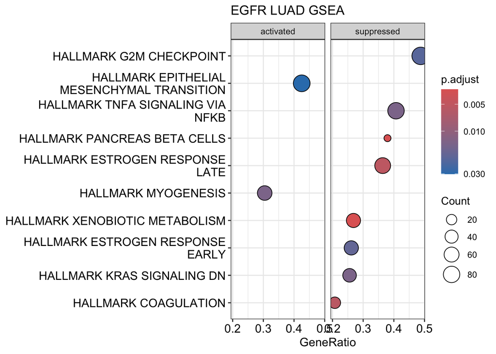

```r
################
# EGFR
################
set.seed(1234)
res_EGFR <- run_edger_deg(
  expr_mat = LUAD_mat_driv,
  meta = luad_meta_driv,
  status_col = "EGFR_status"
)

gene_list_EGFR <- res_EGFR$logFC
names(gene_list_EGFR) <- res_EGFR$SYMBOL
gene_list_EGFR<- sort(gene_list_EGFR, decreasing = TRUE)

msig_res_hall_EGFR <- GSEA(geneList = gene_list_EGFR,
                 TERM2GENE = m_hall_symbol,
                 pvalueCutoff = 0.05,
                 minGSSize = 10,
                 maxGSSize = 500,
                 nPerm = 10000,
                 pAdjustMethod = "BH")



dotplot(msig_res_hall_EGFR, split = ".sign",title="EGFR LUAD GSEA") +
  facet_grid(. ~ .sign)
```